# Intro R Images & Challenges

October 17, 2015

## Motivation

- R is not a GUI, and that's a good thing
- R code is great for reproducibility
- R is interdisciplinary and extensible (image, gis, timeseries, ML)
- R works on data of all shapes and size
- R produces high-quality graphics
- Community
- Open source/cross platform

## R Script

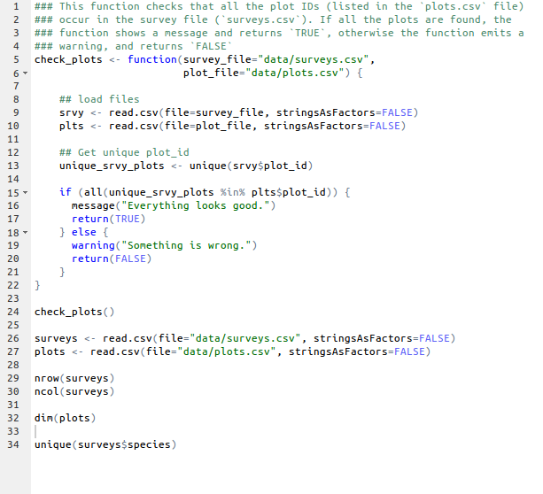

## Current value of weight?

```r
weight_kg <- 57.5
(weight_lb <- 2.2 * weight_kg)
```

```
## [1] 126.5
```

and then change `weight_kg` to 100.

```r
weight_kg <- 100
```

What do you think is the current content of the object `weight_lb`?

- 126.5
- 200

## Weight_lb is:

```r
(weight_lb)
```

```
## [1] 126.5
```

## Challenge 1

What are the values after each statement in the following?

```r
mass <- 47.5            # mass?
age  <- 122             # age?
mass <- mass * 2.0      # mass?
age  <- age - 20        # age?
mass_index <- mass/age  # mass_index?
```

## Challenge 2

Based on the output of str(surveys), can you answer the following questions?

1. What is the class of the object surveys?
2. How many rows and how many columns are in this object?
3. How many species have been recorded during these surveys?
4. As you can see, the columns species and sex are of a special class called factor.

## Challenge 3

```r
## Challenge

## How can you recreate this plot but by having "control" being listed
##last instead of first?
exprmt <- factor(c("treat1", "treat2", "treat1", "treat3", "treat1", "control",
                   "treat1", "treat2", "treat3"))
table(exprmt)
```

```
## exprmt
## control  treat1  treat2  treat3
##       1       4       2       2
```

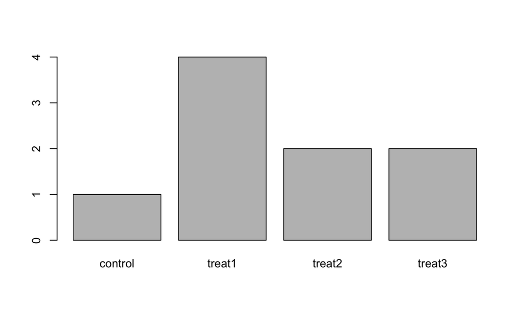

```r
barplot(table(exprmt))
```

## Answer to 3

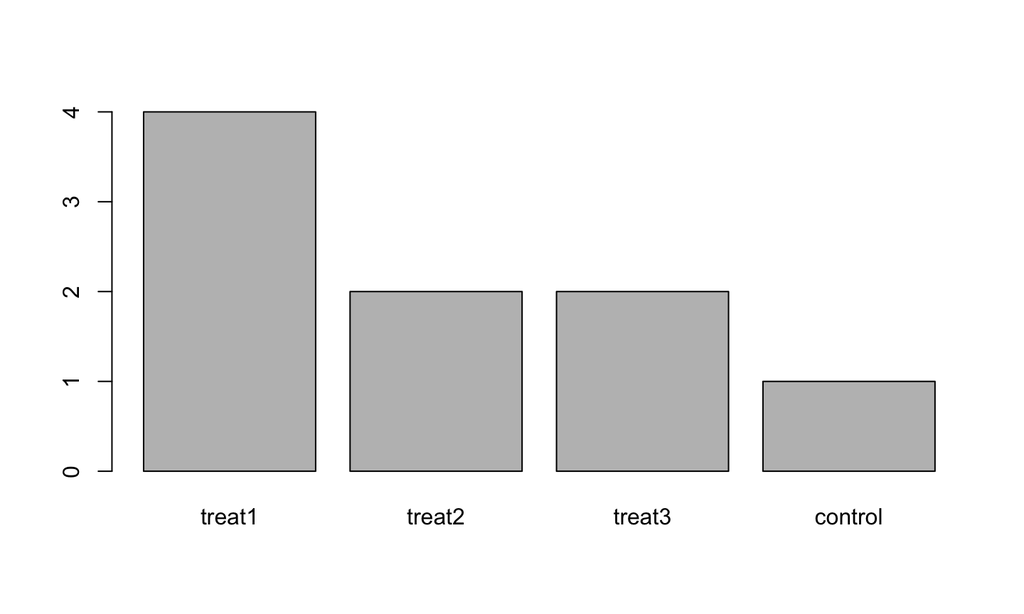

```r
exprmt <- factor(exprmt, levels=c("treat1", "treat2", "treat3", "control"))
barplot(table(exprmt))
```

## Challenge 4

1. There are a few mistakes in this hand crafted `data.frame`, can you spot and fix them? Don't hesitate to experiment!

```
author_book <- data.frame(author_first=c("Charles", "Ernst", "Theodosius"),
                          author_last=c(Darwin, Mayr, Dobzhansky),
                          year=c(1942, 1970))
```

## Challenge 5

Can you predict the class for each of the columns in the following example?

```
cntry_climate<- data.frame(country=c("Canada", "Panama", "South Africa", "Australia"),
                          climate=c("cold", "hot", "temperate", "hot/temperate"),
                          temperature=c(10, 30, 18, "15"),
                          northern_hemisphere=c(TRUE, TRUE, FALSE, "FALSE"),
                          has_kangaroo=c(FALSE, FALSE, FALSE, 1))
```

## Challenge 6

The function nrow() on a data.frame returns the number of rows. Use it, in conjuction with seq() to create a new data.frame called surveys_by_10 that includes every 10th row of the survey data frame starting at row 10 (10, 20, 30, …)